# Annual Business Registration

Larry

[figure not shown]

### Purpose of this document

This document package represents all of the elements pertaining to the process that was selected by your municipality.

Each process typically contains the following elements in a particular order:

1. **Workflow** diagram detailing municipal process
2. **Application** for completion by constituent
3. **Confirmation page** displayed after application submission
4. **Copy of the Application** submitted by the constituent
5. **mail response** to constituent
6. **mail response** notifying admin of a new submission
7. **Admin form** used by municipal employees to process applications
8. **Approval/Denial emails** received by constituent, if applicable
9. **License/Certificate/Permit** generated by the system upon approval

****The documents contained in this sign-off package will be in this order.**

**Note**: Not all processes will contain this exact set of elements. The presence of these elements depends on the workflow itself.

### Instructions/Process for moving forward

1. Review each process and the elements.
2. Approve or edit the elements to fit your workflow as required.
3. Send the approval or modifications for each element back to GovPilot.
4. GovPilot schedules a review to confirm the process elements or any changes.
5. GovPilot sends a final document package for electronic sign-off via DocuSign.
6. Once GovPilot receives the signed document package, development commences.

**Note**: Steps 1-4 repeat as needed in order to proceed to steps 5-6.

### Notes

1. Every mention of YourTown and the presence of the logo, branding, etc. will be replaced with the logo and letterhead of your municipality.
2. Any mention of a person’s name, title and municipality will be replaced with actual names, titles and municipality names unless advised otherwise.
3. The documents requiring review and approval (or disapproval) are arranged in the order of the workflow, which is the diagram that comes before the Application.
4. It is imperative that the actual users are involved in the process element review and discussion.

## **Workflow**

[interactive chart not shown]

#### Workflow related documents:

1. **Application for completion by constituent**
2. Confirmation page displayed after application submission
3. Admin receives automated email from system
4. Admin reviews application
5. Applicant Receives automated approval email from system
6. Applicant receives automated denial email from system
7. Admin issues permit and mails to Applicant

## **Applicant Form**

[interactive chart not shown]

Back to Workflow

## **Confirmation page displayed after application submission**

[figure not shown]

Back to Workflow

**Your Town**

**Annual Business Registration - Approval**

Reference # **ABR-2016-005**

Application Date: 1/8/2016 10:52:00 AM

Dear shr saz,

Your Annual Business Registration application has been APPROVED. The license fee of $100.00 must be paid before a license can be issued.

Payment can be made in person by cash, check or money order. Alternatively payment can be made by mail in the form of a check or money order to:

Your Town

Clerk’s Office

123 Main Ave

Your Town, USA 00000

All checks and money orders must contain the reference number above to enable efficient processing of your payment.

Sincerely,

Administrator/Borough Clerk

Back to Workflow

## **Email response notifying admin of a new submission**

# Annual Business Registration

Reference # **ABR-2016-005**

Application Date: 1/8/2016 10:52:00 AM Application Information

Name: shr saz Address: 7 Arden PL Block: 2205 Lot: 2

Telephone # 2121412421 Email: shravan@govpilot.com

Back to Workflow

## **Admin Form**

[interactive chart not shown]

Back to Workflow

## **Approval email received by constituent**

# Annual Business Registration - Approval

Reference # **ABR-2016-005**

Application Date: 1/8/2016 10:52:00 AM Dear shr saz,

Your Annual Business Registration application has been APPROVED. The license fee of $100.00 must be paid before a license can be issued.

Payment can be made in person by cash, check or money order. Alternatively payment can be made by mail in the form of a check or money order to:

Your Town Clerk's Office 123 Main Ave

Your Town, USA 00000

All checks and money orders must contain the reference number above to enable efficient processing of your payment.

Sincerely, Administrator/Borough Clerk

Back to Workflow

## **Denial email received by constituent**

# Annual Business Registration - Denial

Reference # **ABR-2016-005**

Application Date: 1/8/2016 10:52:00 AM Dear shr saz,

Your Annual Business Registration application has been DENIED. No further action is required.

For more information you may contact us at (555) 555-5555. Sincerely,

Administrator/Borough Clerk

Back to Workflow

## **License generated by the system upon approval**

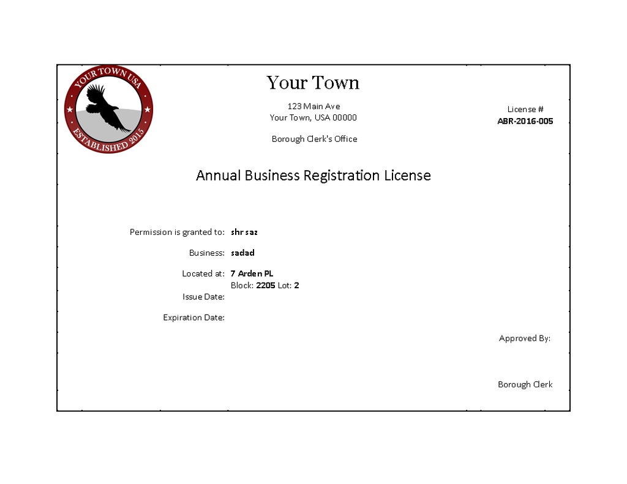

Back to Workflow